# Week 33 Three-Way ANOVA

## Task 1 Solution

Q1) How many respondents’ data are included in the analysis of variance? Quite a few of the overall sample’s respondents have not been included. What, specifically, may be the reason for this?

**Even though we have 1473 participants (id) we see that hapmar only has 792 observations. This number could actually be reduced more as we have missing data in other factors too. This is a general survey with respondents sampled from a large, general population. In this analysis, the DV is a measure of marital happiness. It is likely that most of the missing data occurs for respondents in the sample who are not or have never been married and, thus, cannot respond to the marital happiness measure.**

Q2) Produce the table of marginal means for this study.

**See code below**

Q3) What is the marginal mean marital happiness for female respondents?

**1.38**

Q4) What are the marginal means for the RACE x SEX interaction?

**White males: 1.35. White females: 1.37. Black males: 1.66. Black Females: 1.49**

Q5) Report the F-value, Degrees of freedom and significance level for all effects in the design. How many degrees of freedom are associated with the error term?

**Main effect of race: F(1,579) = .164, p = .685**  
**Main effect of sex: F(1,579) = .563, p = .453**  
**Main effect of paeindex: F(1,579) = 5,826, p = .016**  
**Race x Sex interaction: F(1,579) = .538, p = .464**  
**Race x Paeindex interaction: F(1,579) = 6.219, p = .013**  
**Sex x Paeindex interaction: F(1,579) = 3.775, p = .053**  
**Race x Sex x Paeindex interaction: F(1,579) = 3.753, p = .053**  
**df for error term = 579**

Q6) Assume that the three-way interaction is significant. What interpretation would you offer this effect?

**Based upon inspection of the cell means, there generally appears to be very small differences in marital happiness in relation to the PAEINDEX. However, this seems not to be the case for Black Male respondents. Within this combination of the Race and Gender factors there is noticeably larger difference with respondents in this category whose fathers did not finish high school being less happy in their marriages (high numbers indicate greater marital unhappiness) than those whose fathers had finished high school. This represents a distinctive pattern of marital happiness associated with distinctive combinations of the Race, Sex and PAEINDEX factors.**

Q7) Assuming that the three-way interaction effect is significant, are the other significant effects of interpretative importance? How should effects with such significance levels best be presented?

**This is an issue researchers have been arguing about for decades. Generally, since the marginally significant three-way interaction indicates that marital happiness is complexly related to distinctive combinations of Race, Sex and PAEINDEX, the other significant main and interaction effects are not important to interpretation of the study’s results since the meaning of such effects are qualified by the significant three-way interaction.**

Q8) In the previous questions the three-way interaction effect, with an actual significance level of 0.053, was assumed to be significant. Is this appropriate statistical practice? Why or why not?

**It is not appropriate to treat such an effect as being significant since .053 is not less than .05. However, it is quite customary to consider such effects as being “marginally” significant and to include their consideration in interpretation of a study’s findings. Normally, marginally significant results are regarded with some caution and it is typical to want to see such effects replicated before they are given full stature in the research literature.**

```r
library(haven) ### used to load SPSS .sav files, read_sav()
library(tidyverse) ### for general purpose functions
library(rstatix) ### used for our ANOVA, anova_test()
library(ggpubr) ### used for graphs such as gghistogram()
library(emmeans)
df <- read_sav("gss.sav")
df <- df %>%
  filter(race == 1 | race == 2) ## filter cases for race=1 or race=2, that way we also remove missing values cases
df$sex <-factor(df$sex,
                       levels=c(1,2),
                       labels=c("male", "female"))
df$race <-factor(df$race,
                       levels=c(1,2),
                       labels=c("white", "black"))
df$paeindex <-factor(df$paeindex,
                       levels=c(1,2),
                       labels=c("highschool", "posthighschool"))
## upon inspecting df we see that hapmar is described as unknown
## we convert it to numeric
## this may not happen in all cases but you should always check your variables
df$hapmar <- as.numeric(df$hapmar)
### initial look at the overall dataframe
## we can see the total number of participants from the max id
## Question 1
summary(df)
```

```
##        id          race           age           sex         marital
##  Min.   :   1   white:1251   Min.   :18.0   male  :574   Min.   :1.00
##  1st Qu.: 374   black: 170   1st Qu.:29.0   female:847   1st Qu.:1.00
##  Median : 732                Median :40.0                Median :1.00
##  Mean   : 733                Mean   :44.2                Mean   :2.18
##  3rd Qu.:1093                3rd Qu.:58.5                3rd Qu.:3.00
##  Max.   :1473                Max.   :89.0                Max.   :5.00
##                              NA's   :6
##      satjob        hapmar         life         postlife        educ
##  Min.   :1.0   Min.   :1     Min.   :1.00   Min.   :1.0   Min.   : 0.0
##  1st Qu.:1.0   1st Qu.:1     1st Qu.:1.00   1st Qu.:1.0   1st Qu.:11.0
##  Median :2.0   Median :1     Median :2.00   Median :1.0   Median :12.0
##  Mean   :1.8   Mean   :1     Mean   :1.58   Mean   :1.2   Mean   :12.4
##  3rd Qu.:2.0   3rd Qu.:2     3rd Qu.:2.00   3rd Qu.:1.0   3rd Qu.:14.0
##  Max.   :4.0   Max.   :3     Max.   :3.00   Max.   :2.0   Max.   :20.0
##  NA's   :258   NA's   :629   NA's   :12     NA's   :118   NA's   :3
##      degree         paeduc        maeduc         speduc        income
##  Min.   :0.00   Min.   : 0    Min.   : 0.0   Min.   : 0    Min.   : 1.0
##  1st Qu.:0.00   1st Qu.: 8    1st Qu.: 8.0   1st Qu.:12    1st Qu.: 9.0
##  Median :1.00   Median :11    Median :12.0   Median :12    Median :13.0
##  Mean   :1.16   Mean   :10    Mean   :10.4   Mean   :12    Mean   :11.6
##  3rd Qu.:1.00   3rd Qu.:12    3rd Qu.:12.0   3rd Qu.:14    3rd Qu.:15.0
##  Max.   :4.00   Max.   :20    Max.   :20.0   Max.   :20    Max.   :17.0
##  NA's   :3      NA's   :384   NA's   :219    NA's   :631   NA's   :129
##      health         hompop          agewed          sibs
##  Min.   :1.00   Min.   : 1.00   Min.   :12.0   Min.   : 0.00
##  1st Qu.:1.00   1st Qu.: 2.00   1st Qu.:19.0   1st Qu.: 2.00
##  Median :2.00   Median : 2.00   Median :21.0   Median : 3.00
##  Mean   :1.97   Mean   : 2.69   Mean   :21.9   Mean   : 4.09
##  3rd Qu.:2.00   3rd Qu.: 4.00   3rd Qu.:24.0   3rd Qu.: 6.00
##  Max.   :4.00   Max.   :10.00   Max.   :45.0   Max.   :24.00
##  NA's   :10                     NA's   :284    NA's   :8
##            paeindex      educindx       maeindex
##  highschool    :535   Min.   :1.00   Min.   :1.0
##  posthighschool:478   1st Qu.:1.00   1st Qu.:1.0
##  NA's          :408   Median :2.00   Median :2.0
##                       Mean   :1.73   Mean   :1.5
##                       3rd Qu.:2.00   3rd Qu.:2.0
##                       Max.   :2.00   Max.   :2.0
##                       NA's   :6      NA's   :249
```

```r
## OR
df %>%
  get_summary_stats(hapmar, type = "mean_sd")
```

```
## # A tibble: 1 x 4
##   variable     n  mean    sd
##   <chr>    <dbl> <dbl> <dbl>
## 1 hapmar     792  1.38 0.544
```

```r
### getting marginal means
### grouping per race, sex, and parental educationindex
df %>%
  group_by(race, sex, paeindex) %>%
  get_summary_stats(hapmar, type = "mean_sd")
```

```
## # A tibble: 12 x 7
##    race  sex    paeindex       variable     n  mean    sd
##    <fct> <fct>  <fct>          <chr>    <dbl> <dbl> <dbl>
##  1 white male   highschool     hapmar     143  1.34 0.543
##  2 white male   posthighschool hapmar      99  1.34 0.477
##  3 white male   <NA>           hapmar      70  1.4  0.549
##  4 white female highschool     hapmar     159  1.33 0.524
##  5 white female posthighschool hapmar     149  1.34 0.517
##  6 white female <NA>           hapmar     102  1.45 0.607
##  7 black male   highschool     hapmar      12  1.92 0.669
##  8 black male   posthighschool hapmar       3  1    0
##  9 black male   <NA>           hapmar      14  1.57 0.514
## 10 black female highschool     hapmar      14  1.36 0.497
## 11 black female posthighschool hapmar       8  1.25 0.463
## 12 black female <NA>           hapmar      19  1.68 0.671
```

```r
### grouping per sex
### Question 3
df %>%
  group_by(sex) %>%
  get_summary_stats(hapmar, type = "mean_sd")
```

```
## # A tibble: 2 x 5
##   sex    variable     n  mean    sd
##   <fct>  <chr>    <dbl> <dbl> <dbl>
## 1 male   hapmar     341  1.38 0.537
## 2 female hapmar     451  1.38 0.55
```

```r
## marginal means for race x sex
### grouping per race, sex
### Question 4
df %>%
  group_by(race, sex) %>%
  get_summary_stats(hapmar, type = "mean_sd")
```

```
## # A tibble: 4 x 6
##   race  sex    variable     n  mean    sd
##   <fct> <fct>  <chr>    <dbl> <dbl> <dbl>
## 1 white male   hapmar     312  1.35 0.523
## 2 white female hapmar     410  1.37 0.544
## 3 black male   hapmar      29  1.66 0.614
## 4 black female hapmar      41  1.49 0.597
```

```r
### as discussed in week 30, the following are all possible ways to carry out the ANOVA
### Question 5
df %>%
  anova_test(hapmar ~ race*sex*paeindex, type = 3, detailed = TRUE)
```

```
## ANOVA Table (type III tests)
##
##              Effect     SSn SSd DFn DFd       F        p p<.05      ges
## 1       (Intercept) 183.993 157   1 579 679.762 1.04e-99     * 0.540000
## 2              race   0.044 157   1 579   0.164 6.85e-01       0.000284
## 3               sex   0.152 157   1 579   0.563 4.53e-01       0.000971
## 4          paeindex   1.577 157   1 579   5.826 1.60e-02     * 0.010000
## 5          race:sex   0.146 157   1 579   0.538 4.64e-01       0.000928
## 6     race:paeindex   1.683 157   1 579   6.219 1.30e-02     * 0.011000
## 7      sex:paeindex   1.022 157   1 579   3.775 5.30e-02       0.006000
## 8 race:sex:paeindex   1.016 157   1 579   3.753 5.30e-02       0.006000
```

```r
model <-lm(hapmar ~ race*sex*paeindex, data=df,
          contrasts=list(race=contr.sum, sex=contr.sum, paeindex=contr.sum),
          type = 3)
car::Anova(model, type=3)
```

```
## Anova Table (Type III tests)
##
## Response: hapmar
##                   Sum Sq  Df F value Pr(>F)
## (Intercept)        184.0   1  679.76 <2e-16 ***
## race                 0.0   1    0.16  0.685
## sex                  0.2   1    0.56  0.453
## paeindex             1.6   1    5.83  0.016 *
## race:sex             0.1   1    0.54  0.464
## race:paeindex        1.7   1    6.22  0.013 *
## sex:paeindex         1.0   1    3.78  0.053 .
## race:sex:paeindex    1.0   1    3.75  0.053 .
## Residuals          156.7 579
## ---
## Signif. codes:  0 '***' 0.001 '**' 0.01 '*' 0.05 '.' 0.1 ' ' 1
```

```r
### you should not use the following way as the design is not balanced
result.aov <- aov(hapmar ~ race*sex*paeindex, data=df)
summary(result.aov)
```

```
##                    Df Sum Sq Mean Sq F value Pr(>F)
## race                1    0.8   0.762    2.82  0.094 .
## sex                 1    0.1   0.103    0.38  0.537
## paeindex            1    0.0   0.026    0.09  0.759
## race:sex            1    1.4   1.427    5.27  0.022 *
## race:paeindex       1    1.0   0.998    3.69  0.055 .
## sex:paeindex        1    0.1   0.053    0.20  0.658
## race:sex:paeindex   1    1.0   1.016    3.75  0.053 .
## Residuals         579  156.7   0.271
## ---
## Signif. codes:  0 '***' 0.001 '**' 0.01 '*' 0.05 '.' 0.1 ' ' 1
## 834 observations deleted due to missingness
```

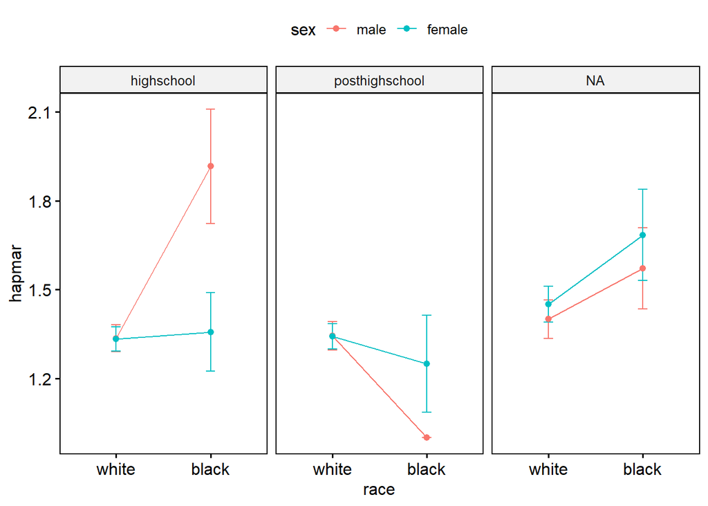

```r
## the following is just an example on how to inspect this visually
## ggline requires ggpubr
## in your lecture slides we also used ggplot2
## you can try using ggplot2 for more practice
ggline(df, x = "race", y = "hapmar",
       color = "sex",  ###instead of color you could use line etc
       facet.by = "paeindex",
       add = "mean_se")
```

## Task 2 : Simple effects analysis with a 2 x 2 x 2 between subjects design.

[output not shown]

1. Looking at the interaction between the father’s education level and sex on how happily married respondents are, when white.
2. Looking at the interaction between the father’s education level and sex on how happily married respondents are, when black.

Q1) Report the F-value, degrees of freedom, and significance level for each tested simple interaction and main effect.

Q2) Give a verbal interpretation of each tested simple effect.

Q3) Given the pattern of simple effects, what interpretation would you offer for the (marginally) significant three-way interaction in the ANOVA?

## Task 2: Solution

Q1) Report the F-value, degrees of freedom and significance level for each tested simple interaction and main effect.

**F(1,579) < 0.001, p = .990**  
**F(1,579) = 3.949, p = .047**

Q2) Give a verbal interpretation of each tested simple effect.

**Simple Sex by Paeindex interaction within the White condition are distinctive levels of marital happiness associated with distinctive levels of Sex and the PAEINDEX for the White respondents? Simple Sex by Paeindex interaction within the Black condition are distinctive levels of marital happiness associated with distinctive levels of Sex and the PAEINDEX for the Black respondents?**

Q3) Given the pattern of simple effects, what interpretation would you offer for the (marginally) significant three-way interaction in the ANOVA?

**Within Black respondents, the respondent’s father’s education has more of an effect on the happiness of their marriage when the respondent is male than it does when they are female. Among White respondents, sex does not affect whether father’s education itself effects happiness of marriage.**

```r
## As per your lecture slides we have to use lm() and define the model
mmodel <-lm(hapmar ~ race*sex*paeindex, data=df,
          contrasts=list(race=contr.sum, sex=contr.sum, paeindex=contr.sum),
          type = 3)
## we then use the emmeans package
## specifically the functions joint_test() for simple main effects
## within the levels of the second factor
simple <- joint_tests(model, by ="race")
simple
```

```
## race = white:
##  model term   df1 df2 F.ratio p.value
##  sex            1 579   0.000  0.9690
##  paeindex       1 579   0.030  0.8530
##  sex:paeindex   1 579   0.000  0.9900
##
## race = black:
##  model term   df1 df2 F.ratio p.value
##  sex            1 579   0.580  0.4480
##  paeindex       1 579   6.320  0.0120
##  sex:paeindex   1 579   3.950  0.0470
```

```r
## The following is not required by the question
## we provide it as a demonstration of how to follow-up
## for pairwise comparisons and acquiring estimated means
## note that these estimated means may differ than the original means
## you acquired in task 1.
## we then follow this up with emmeans()
## in order to get pairwise comparisons
## and marginal means
## we declare our model, and the order or variables
simple_sex <- emmeans(model,  ~ sex * paeindex | race)
## we call pairs() to run the pairwise comparisons
simple_sex %>%
  pairs()
```

```
## race = white:
##  contrast                                    estimate    SE  df t.ratio p.value
##  male highschool - female highschool            0.002 0.060 579   0.039  1.0000
##  male highschool - male posthighschool         -0.008 0.068 579  -0.114  0.9990
##  male highschool - female posthighschool       -0.007 0.061 579  -0.109  1.0000
##  female highschool - male posthighschool       -0.010 0.067 579  -0.152  0.9990
##  female highschool - female posthighschool     -0.009 0.059 579  -0.151  0.9990
##  male posthighschool - female posthighschool    0.001 0.067 579   0.017  1.0000
##
## race = black:
##  contrast                                    estimate    SE  df t.ratio p.value
##  male highschool - female highschool            0.560 0.205 579   2.734  0.0330
##  male highschool - male posthighschool          0.917 0.336 579   2.730  0.0330
##  male highschool - female posthighschool        0.667 0.237 579   2.807  0.0260
##  female highschool - male posthighschool        0.357 0.331 579   1.079  0.7030
##  female highschool - female posthighschool      0.107 0.231 579   0.465  0.9670
##  male posthighschool - female posthighschool   -0.250 0.352 579  -0.710  0.8930
##
## P value adjustment: tukey method for comparing a family of 4 estimates
```

```r
## print() displays the marginal means
print(simple_sex)
```

```
## race = white:
##  sex    paeindex       emmean     SE  df lower.CL upper.CL
##  male   highschool       1.34 0.0435 579    1.250     1.42
##  female highschool       1.33 0.0413 579    1.252     1.41
##  male   posthighschool   1.34 0.0523 579    1.241     1.45
##  female posthighschool   1.34 0.0426 579    1.259     1.43
##
## race = black:
##  sex    paeindex       emmean     SE  df lower.CL upper.CL
##  male   highschool       1.92 0.1502 579    1.622     2.21
##  female highschool       1.36 0.1390 579    1.084     1.63
##  male   posthighschool   1.00 0.3004 579    0.410     1.59
##  female posthighschool   1.25 0.1839 579    0.889     1.61
##
## Confidence level used: 0.95
```